# Logistic Regression for Loansharks (2016 Pennsylvania)

# Cross validation

```
Model summary


Call:
NULL

Deviance Residuals:
    Min       1Q   Median       3Q      Max
-3.1410  -0.5411   0.4978   0.7461   4.9664

Coefficients:
                                                                                                                  Estimate
(Intercept)                                                                                                      0.4200909
applicant_race_and_ethnicityAsian                                                                                0.7000976
`applicant_race_and_ethnicityBlack or African American`                                                          0.2612487
`applicant_race_and_ethnicityHispanic or Latino`                                                                 0.3795999
`applicant_race_and_ethnicityInformation not provided by applicant in mail, Internet, or telephone application`  0.5868782
`applicant_race_and_ethnicityNative Hawaiian or Other Pacific Islander`                                          0.5536262
`applicant_race_and_ethnicityNot applicable`                                                                     2.6307586
applicant_race_and_ethnicityWhite                                                                                0.9167046
owner_occupancy2                                                                                                -0.1727847
owner_occupancy3                                                                                                -0.1577008
preapproval2                                                                                                    -0.4588457
preapproval3                                                                                                    -0.6568419
log_loan_amount_000s                                                                                             0.0723806
applicant_sex2                                                                                                  -0.0693746
applicant_sex3                                                                                                  -0.0388430
applicant_sex4                                                                                                  -0.8009931
county_code11                                                                                                   -0.0756378
county_code125                                                                                                   0.1479346
county_code129                                                                                                   0.0516541
county_code13                                                                                                   -0.1017173
county_code133                                                                                                  -0.0704112
county_code17                                                                                                    0.1584074
county_code19                                                                                                    0.1747046
county_code27                                                                                                    0.1667199
county_code29                                                                                                    0.3071402
county_code3                                                                                                     0.1796490
county_code41                                                                                                    0.2016670
county_code43                                                                                                    0.1271792
```

[output cut: 498 more lines]

```
respondent_id7734800004                                                                                         ***
respondent_id7810600004                                                                                         ***
respondent_idother                                                                                              ***
---
Signif. codes:  0 ‘***’ 0.001 ‘**’ 0.01 ‘*’ 0.05 ‘.’ 0.1 ‘ ’ 1

(Dispersion parameter for binomial family taken to be 1)

    Null deviance: 280130  on 231568  degrees of freedom
Residual deviance: 222096  on 231464  degrees of freedom
AIC: 222306

Number of Fisher Scoring iterations: 6

Anova for model
```

[output not shown]

```
Analysis of Deviance Table

Model: binomial, link: logit

Response: .outcome

Terms added sequentially (first to last)

                                                                                                                Df
NULL
applicant_race_and_ethnicityAsian                                                                                1
`applicant_race_and_ethnicityBlack or African American`                                                          1
`applicant_race_and_ethnicityHispanic or Latino`                                                                 1
`applicant_race_and_ethnicityInformation not provided by applicant in mail, Internet, or telephone application`  1
`applicant_race_and_ethnicityNative Hawaiian or Other Pacific Islander`                                          1
`applicant_race_and_ethnicityNot applicable`                                                                     1
applicant_race_and_ethnicityWhite                                                                                1
owner_occupancy2                                                                                                 1
owner_occupancy3                                                                                                 1
preapproval2                                                                                                     1
preapproval3                                                                                                     1
log_loan_amount_000s                                                                                             1
applicant_sex2                                                                                                   1
applicant_sex3                                                                                                   1
applicant_sex4                                                                                                   1
county_code11                                                                                                    1
county_code125                                                                                                   1
county_code129                                                                                                   1
county_code13                                                                                                    1
county_code133                                                                                                   1
county_code17                                                                                                    1
county_code19                                                                                                    1
county_code27                                                                                                    1
county_code29                                                                                                    1
county_code3                                                                                                     1
county_code41                                                                                                    1
county_code43                                                                                                    1
county_code45                                                                                                    1
county_code49                                                                                                    1
county_code55                                                                                                    1
```

[output cut: 591 more lines]

```
`respondent_id37-1542226`                                                                                       ***
`respondent_id38-2750395`                                                                                       ***
`respondent_id41-1795868`                                                                                       **
`respondent_id62-1532940`                                                                                       ***
respondent_id7015500006                                                                                         ***
respondent_id7162800002                                                                                         ***
respondent_id7197000003                                                                                         ***
`respondent_id75-2921540`                                                                                       ***
respondent_id7505400005                                                                                         ***
respondent_id7527300003
respondent_id7734800004                                                                                         ***
respondent_id7810600004                                                                                         ***
respondent_idother                                                                                              ***
---
Signif. codes:  0 ‘***’ 0.001 ‘**’ 0.01 ‘*’ 0.05 ‘.’ 0.1 ‘ ’ 1
```

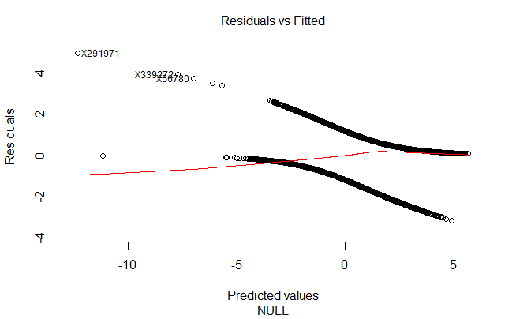

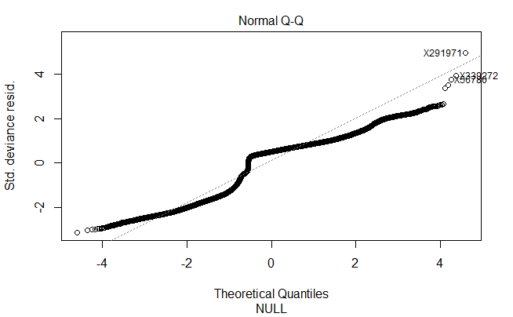

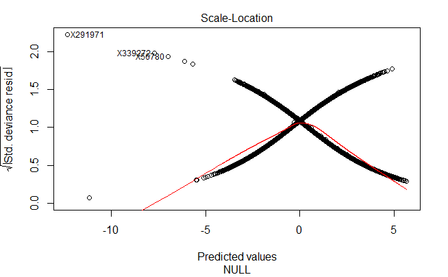

```
optimal cut threshold is
                 [,1]
sensitivity 0.7237493
specificity 0.6990377
cutoff      0.7203076
```

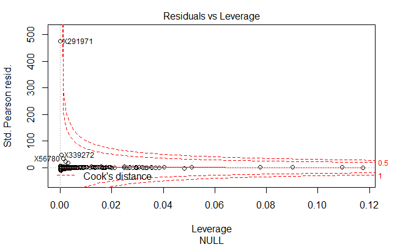

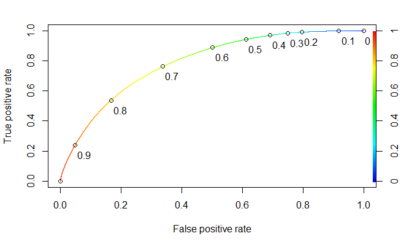

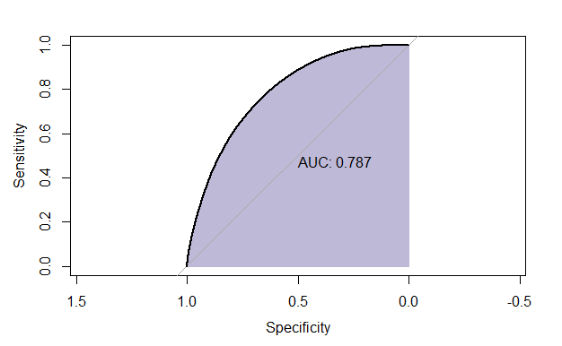

```r
model_2016_cross_val_loan_income_ratio <- cross_validation("loan_granted~applicant_race_and_ethnicity+owner_occupancy+preapproval+log_loan_amount_000s+applicant_sex+county_code+tract_to_msamd_income+co_applicant_present+agency_code+minority_population+loan_purpose+rate_spread+property_type+loan_to_income_ratio+respondent_id", train)

model_summary_and_plot(model_2016_cross_val_loan_income_ratio$finalModel, train)
```

# Model performance.

```r
library(ROCR)
library(pROC)
model1_fitted.probs <- predict(model_2016_income_loan_amount, test, type = "response")
model2_fitted.probs <- predict(model_2016_log_income_loan_amount, test, type = "response")
model3_fitted.probs <- predict(model_2016_ratio_of_loan_to_income_with_log_of_income_and_amount, test, type = "response")

writeLines("")
```

```r
writeLines("Model 1 performance")
```

```
Model 1 performance
```

```
[1] "no"  "yes"
[1] "Accuracy 0.773816309961825"
Confusion Matrix and Statistics

          Reference
Prediction    no   yes
       no   8484  4614
       yes  8480 36313

               Accuracy : 0.7738
                 95% CI : (0.7704, 0.7772)
    No Information Rate : 0.707
    P-Value [Acc > NIR] : < 0.00000000000000022

                  Kappa : 0.4151

 Mcnemar's Test P-Value : < 0.00000000000000022

            Sensitivity : 0.8873
            Specificity : 0.5001
         Pos Pred Value : 0.8107
         Neg Pred Value : 0.6477
             Prevalence : 0.7070
         Detection Rate : 0.6273
   Detection Prevalence : 0.7737
      Balanced Accuracy : 0.6937

       'Positive' Class : yes

Confusion Matrix and Statistics

          Reference
Prediction    no   yes
       no   8484  4614
       yes  8480 36313

               Accuracy : 0.7738
                 95% CI : (0.7704, 0.7772)
    No Information Rate : 0.707
    P-Value [Acc > NIR] : < 0.00000000000000022
```

[output cut: 11 more lines]

```
   Detection Prevalence : 0.7737
      Balanced Accuracy : 0.6937

       'Positive' Class : yes

[1] "Precision not found"
[1] "Prevalence"
[1] "Precision and Recall"
[1] 0.8106847
[1] 0.8872627
[[1]]
[1] 0.8106847

[[2]]
[1] 0.8872627
```

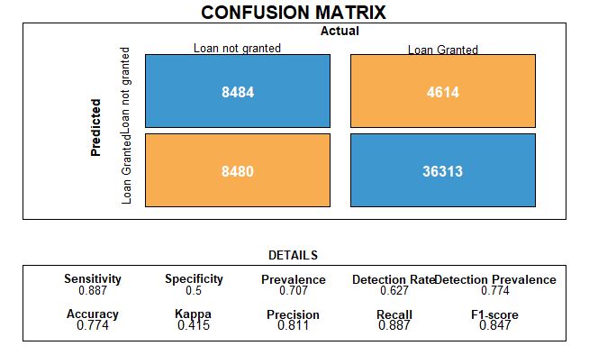

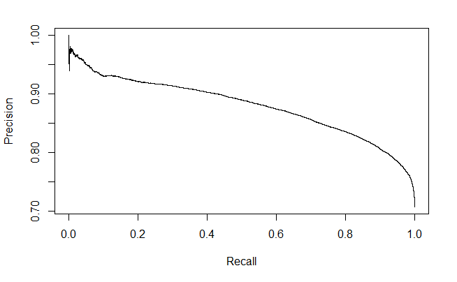

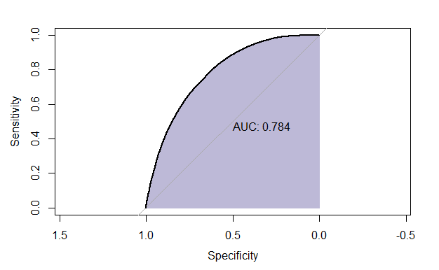

```r
print_model_performance(model1_fitted.probs, test, positive = "yes", negative = "no", threshold = 0.6)
```

```r
writeLines("")
```

```r
writeLines("Model 2 performance")
```

```
Model 2 performance
```

```
[1] "no"  "yes"
[1] "Accuracy 0.778549342730304"
Confusion Matrix and Statistics

          Reference
Prediction    no   yes
       no   8858  4714
       yes  8106 36213

               Accuracy : 0.7785
                 95% CI : (0.7751, 0.7819)
    No Information Rate : 0.707
    P-Value [Acc > NIR] : < 0.00000000000000022

                  Kappa : 0.4323

 Mcnemar's Test P-Value : < 0.00000000000000022

            Sensitivity : 0.8848
            Specificity : 0.5222
         Pos Pred Value : 0.8171
         Neg Pred Value : 0.6527
             Prevalence : 0.7070
         Detection Rate : 0.6255
   Detection Prevalence : 0.7656
      Balanced Accuracy : 0.7035

       'Positive' Class : yes

Confusion Matrix and Statistics

          Reference
Prediction    no   yes
       no   8858  4714
       yes  8106 36213

               Accuracy : 0.7785
                 95% CI : (0.7751, 0.7819)
    No Information Rate : 0.707
    P-Value [Acc > NIR] : < 0.00000000000000022
```

[output cut: 11 more lines]

```
   Detection Prevalence : 0.7656
      Balanced Accuracy : 0.7035

       'Positive' Class : yes

[1] "Precision not found"
[1] "Prevalence"
[1] "Precision and Recall"
[1] 0.8170988
[1] 0.8848193
[[1]]
[1] 0.8170988

[[2]]
[1] 0.8848193
```

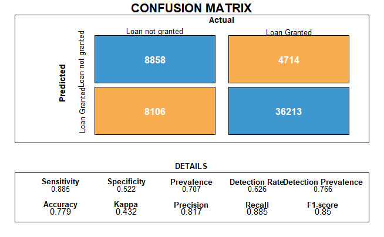

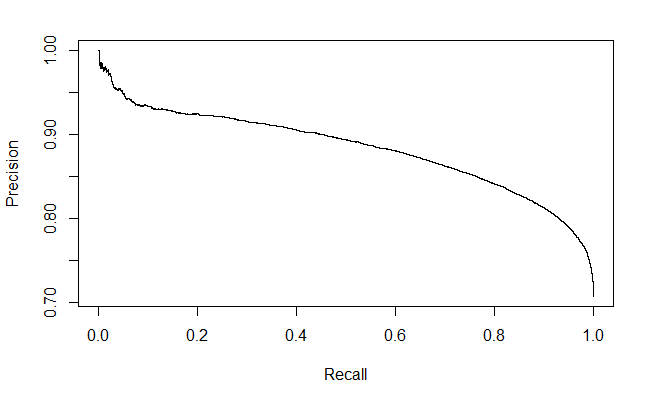

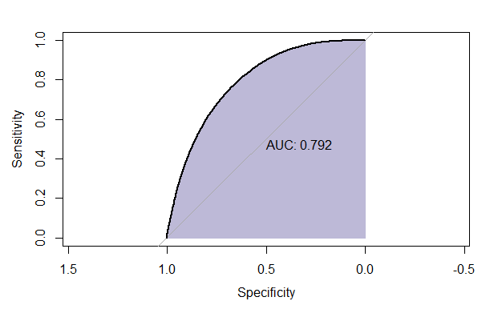

```r
print_model_performance(model2_fitted.probs, test, positive = "yes", negative = "no", threshold = 0.6)
```

```r
writeLines("")
```

```r
writeLines("Model 3 performance")
```

```
Model 3 performance
```

```
[1] "no"  "yes"
[1] "Accuracy 0.773557202328514"
Confusion Matrix and Statistics

          Reference
Prediction    no   yes
       no   8471  4616
       yes  8493 36311

               Accuracy : 0.7736
                 95% CI : (0.7701, 0.777)
    No Information Rate : 0.707
    P-Value [Acc > NIR] : < 0.00000000000000022

                  Kappa : 0.4143

 Mcnemar's Test P-Value : < 0.00000000000000022

            Sensitivity : 0.8872
            Specificity : 0.4994
         Pos Pred Value : 0.8104
         Neg Pred Value : 0.6473
             Prevalence : 0.7070
         Detection Rate : 0.6272
   Detection Prevalence : 0.7739
      Balanced Accuracy : 0.6933

       'Positive' Class : yes

Confusion Matrix and Statistics

          Reference
Prediction    no   yes
       no   8471  4616
       yes  8493 36311

               Accuracy : 0.7736
                 95% CI : (0.7701, 0.777)
    No Information Rate : 0.707
    P-Value [Acc > NIR] : < 0.00000000000000022
```

[output cut: 11 more lines]

```
   Detection Prevalence : 0.7739
      Balanced Accuracy : 0.6933

       'Positive' Class : yes

[1] "Precision not found"
[1] "Prevalence"
[1] "Precision and Recall"
[1] 0.810441
[1] 0.8872138
[[1]]
[1] 0.810441

[[2]]
[1] 0.8872138
```

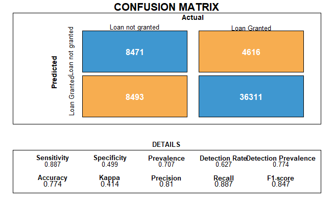

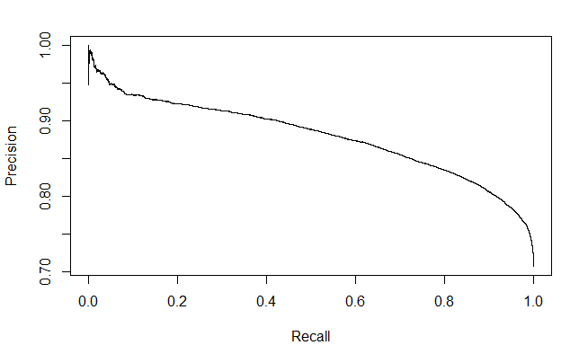

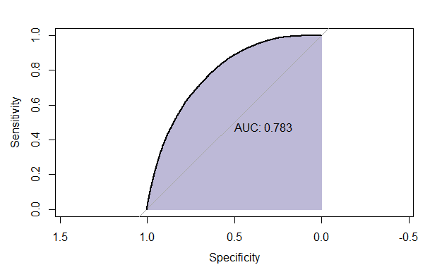

```r
print_model_performance(model3_fitted.probs, test, positive = "yes", negative = "no", threshold = 0.6)
```

# Cross validation performance

```r
library(pROC)

model4_fitted.probs <- predict(model_2016_cross_val_loan_income_ratio, test, type = "prob")
writeLines("")
```

```r
writeLines("Cross validation model performance")
```

```
Cross validation model performance
```

```r
writeLines("")
```

```r
writeLines("Model 3 performance")
```

```
Model 3 performance
```

```
[1] "no"  "yes"
[1] "Accuracy 0.773557202328514"
Confusion Matrix and Statistics

          Reference
Prediction    no   yes
       no   8471  4616
       yes  8493 36311

               Accuracy : 0.7736
                 95% CI : (0.7701, 0.777)
    No Information Rate : 0.707
    P-Value [Acc > NIR] : < 0.00000000000000022

                  Kappa : 0.4143

 Mcnemar's Test P-Value : < 0.00000000000000022

            Sensitivity : 0.8872
            Specificity : 0.4994
         Pos Pred Value : 0.8104
         Neg Pred Value : 0.6473
             Prevalence : 0.7070
         Detection Rate : 0.6272
   Detection Prevalence : 0.7739
      Balanced Accuracy : 0.6933

       'Positive' Class : yes

Confusion Matrix and Statistics

          Reference
Prediction    no   yes
       no   8471  4616
       yes  8493 36311

               Accuracy : 0.7736
                 95% CI : (0.7701, 0.777)
    No Information Rate : 0.707
    P-Value [Acc > NIR] : < 0.00000000000000022
```

[output cut: 11 more lines]

```
   Detection Prevalence : 0.7739
      Balanced Accuracy : 0.6933

       'Positive' Class : yes

[1] "Precision not found"
[1] "Prevalence"
[1] "Precision and Recall"
[1] 0.810441
[1] 0.8872138
[[1]]
[1] 0.810441

[[2]]
[1] 0.8872138
```

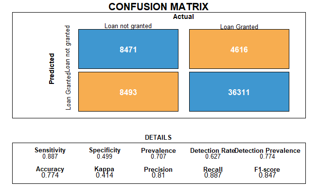

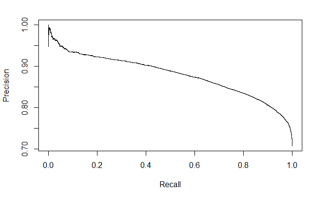

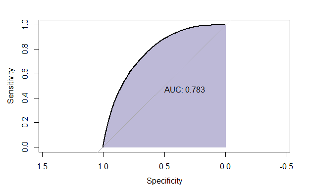

```r
print_model_performance(model4_fitted.probs[, 2], test, positive = "yes", negative = "no", threshold = 0.6)
```

# Model with census data integrated.

```r
# https://www2.census.gov/programs-surveys/popest/datasets/2010-2018/counties/asrh/
census_pa_file_path <- paste(census_data_dir, sep = "", "/cc-est2018-alldata-42.csv")

merged_hmda_data_df_for_model <- merge_hmda_df_with_census(census_pa_file_path, hmda_data_df_for_model)

split_dfs <- train_test_split(merged_hmda_data_df_for_model$loan_granted, merged_hmda_data_df_for_model)

merged_train <- split_dfs[[1]]
merged_test <- split_dfs[[2]]

merged_2016_model <- build_glm_model("loan_granted~applicant_race_and_ethnicity+owner_occupancy+preapproval+property_type+log_loan_amount_000s+tract_to_msamd_income+co_applicant_present+agency_code+BLACK_PERCENT+ASIAN_PERCENT+HISPANIC_PERCENT+county_code+respondent_id+applicant_sex+loan_purpose+loan_to_income_ratio", merged_train)

model5_fitted.probs <- predict(merged_2016_model, merged_test, type = "response")

writeLines("")
```

```r
writeLines("Merged model performance")
```

```
Merged model performance
```

```
[1] "no"  "yes"
[1] "Accuracy 0.772295883969782"
Confusion Matrix and Statistics

          Reference
Prediction    no   yes
       no   8454  4691
       yes  8481 36221

               Accuracy : 0.7723
                 95% CI : (0.7689, 0.7757)
    No Information Rate : 0.7072
    P-Value [Acc > NIR] : < 0.00000000000000022

                  Kappa : 0.4115

 Mcnemar's Test P-Value : < 0.00000000000000022

            Sensitivity : 0.8853
            Specificity : 0.4992
         Pos Pred Value : 0.8103
         Neg Pred Value : 0.6431
             Prevalence : 0.7072
         Detection Rate : 0.6262
   Detection Prevalence : 0.7728
      Balanced Accuracy : 0.6923

       'Positive' Class : yes

Confusion Matrix and Statistics

          Reference
Prediction    no   yes
       no   8454  4691
       yes  8481 36221

               Accuracy : 0.7723
                 95% CI : (0.7689, 0.7757)
    No Information Rate : 0.7072
    P-Value [Acc > NIR] : < 0.00000000000000022
```

[output cut: 11 more lines]

```
   Detection Prevalence : 0.7728
      Balanced Accuracy : 0.6923

       'Positive' Class : yes

[1] "Precision not found"
[1] "Prevalence"
[1] "Precision and Recall"
[1] 0.8102769
[1] 0.8853393
[[1]]
[1] 0.8102769

[[2]]
[1] 0.8853393
```

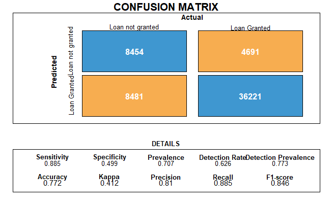

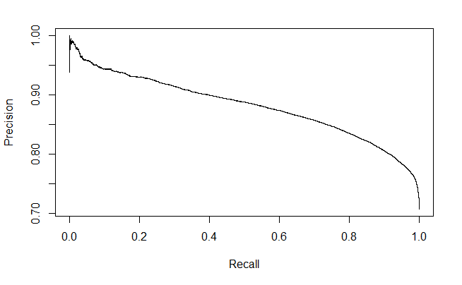

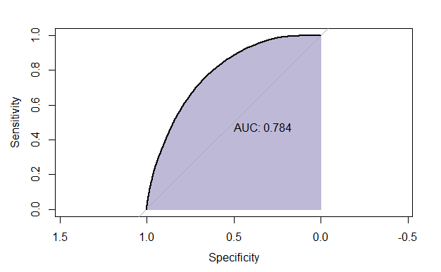

```r
print_model_performance(model5_fitted.probs, merged_test, positive = "yes", negative = "no", threshold = 0.6)
```

# Loan to value ratio is an important metric which banks use to decide

# whether a loan should be granted or not. For e.g. the higher the loan

# to value ratio the riskier it is for the bank.

# https://en.wikipedia.org/wiki/Loan-to-value_ratio

# Banks are not required to report this metric in the HMDA reporting

# law. We use the median of the home values in that county based on

# data available from zillow https://www.zillow.com/research/data/

```r
period_list <- c("2016-01", "2016-02", "2016-03", "2016-04",
                 "2016-05", "2016-06", "2016-07", "2016-08",
                 "2016-09", "2016-10", "2016-11", "2016-12")

merged_hmda_with_loan_to_value_ratio <- augment_hmda_data_with_estimated_loan_to_value_ratio_from_zillow(paste(data_dir, "/zillow/counties_home_value_per_year.csv", sep = ""), hmda_data_df_for_model, "PA", period_list)
```

```
 [1] "2016-01"    "2016-02"    "2016-03"    "2016-04"    "2016-05"
 [6] "2016-06"    "2016-07"    "2016-08"    "2016-09"    "2016-10"
[11] "2016-11"    "2016-12"    "RegionName"
```

```r
head(merged_hmda_with_loan_to_value_ratio)
```

|  | county_name | applicant_race_and_ethnicity | applicant_income_000s | co_applicant_race_and_ethnicity | co_applicant_sex | hoepa_status | lien_status | msamd | owner_occupancy | preapproval | purchaser_type | property_type | loan_amount_000s | applicant_sex | hud_median_family_income | tract_to_msamd_income | loan_to_income_ratio | agency_code | minority_population | loan_purpose | rate_spread | population | number_of_owner_occupied_units | loan_granted | log_loan_amount_000s | log_applicant_income_000s | credit_score | co_applicant_present | respondent_id | … |
| --- | --- | --- | --- | --- | --- | --- | --- | --- | --- | --- | --- | --- | --- | --- | --- | --- | --- | --- | --- | --- | --- | --- | --- | --- | --- | --- | --- | --- | --- | --- |
| 1 | Adams County | White | 87 | No co-applicant | 5 | 2 | 1 | 23900 | 1 | 2 | 1 | 1 | 136 | 1 | 68500 | 82.87 | 1.563218 | 9 | 6.93 | 1 | 1.57 | 5163 | 1507 | yes | 4.912655 | 4.465908 | 734 | 0 | 0000501105 | … |
| 2 | Adams County | White | 92 | White | 2 | 2 | 1 | 23900 | 1 | 3 | 1 | 1 | 240 | 1 | 68500 | 110.39 | 2.608696 | 9 | 11.22 | 3 | 2.48 | 3975 | 1215 | yes | 5.480639 | 4.521789 | 734 | 1 | 0000451965 | … |
| 3 | Adams County | White | 15 | No co-applicant | 5 | 2 | 1 | 23900 | 1 | 3 | 0 | 2 | 48 | 1 | 56000 | 91.69 | 3.200000 | 7 | 10.35 | 1 | 7.44 | 1388 | 466 | no | 3.871201 | 2.708050 | 734 | 0 | 7162800002 | … |
| 4 | Adams County | White | 63 | White | 2 | 2 | 1 | 23900 | 1 | 3 | 6 | 1 | 200 | 1 | 68500 | 113.53 | 3.174603 | 7 | 3.78 | 1 | 2.18 | 2700 | 858 | yes | 5.298317 | 4.143135 | 734 | 1 | 26-3295749 | … |
| 5 | Adams County | White | 78 | No co-applicant | 5 | 2 | 1 | 23900 | 1 | 3 | 3 | 1 | 120 | 1 | 68500 | 91.07 | 1.538462 | 7 | 5.16 | 3 | 1.86 | 4434 | 1234 | yes | 4.787492 | 4.356709 | 734 | 0 | 38-2750395 | … |
| 6 | Adams County | White | 88 | White | 2 | 2 | 1 | 23900 | 1 | 3 | 3 | 1 | 120 | 1 | 68500 | 104.76 | 1.363636 | 7 | 10.21 | 3 | 2.55 | 4928 | 1231 | yes | 4.787492 | 4.477337 | 734 | 1 | 41-1795868 | … |

```r
NA
```

# Train test split on the hmda dataset merged with estimated loan to value

# ratio

```r
split_dfs <- train_test_split(merged_hmda_with_loan_to_value_ratio$loan_granted, merged_hmda_with_loan_to_value_ratio)
new_train <- split_dfs[[1]]
new_test <- split_dfs[[2]]
```

## Model with estimated loan to value ratio.

```
Model summary


Call:
glm(formula = as.formula(model_formula), family = binomial(link = "logit"),
    data = train_df, control = glm.control(maxit = iter))

Deviance Residuals:
    Min       1Q   Median       3Q      Max
-3.9525  -0.5401   0.4983   0.7462   7.3282

Coefficients:
                                                                                                                Estimate
(Intercept)                                                                                                    0.3708070
applicant_race_and_ethnicityAsian                                                                              0.7373686
applicant_race_and_ethnicityBlack or African American                                                          0.2999529
applicant_race_and_ethnicityHispanic or Latino                                                                 0.4224236
applicant_race_and_ethnicityInformation not provided by applicant in mail, Internet, or telephone application  0.6368806
applicant_race_and_ethnicityNative Hawaiian or Other Pacific Islander                                          0.4656107
applicant_race_and_ethnicityNot applicable                                                                     2.1986062
applicant_race_and_ethnicityWhite                                                                              0.9398995
owner_occupancy2                                                                                              -0.1693281
owner_occupancy3                                                                                              -0.1585623
preapproval2                                                                                                  -0.4822451
preapproval3                                                                                                  -0.6904102
log_loan_amount_000s                                                                                           0.0645947
applicant_sex2                                                                                                -0.0748094
applicant_sex3                                                                                                -0.0570692
applicant_sex4                                                                                                -0.3027257
county_code11                                                                                                 -0.1165700
county_code125                                                                                                 0.1071849
county_code129                                                                                                 0.0734518
county_code13                                                                                                 -0.1516284
county_code133                                                                                                -0.0668845
county_code17                                                                                                  0.1660694
county_code19                                                                                                  0.1685164
county_code27                                                                                                  0.1931354
county_code29                                                                                                  0.3069177
county_code3                                                                                                   0.1677173
county_code41                                                                                                  0.1832629
```

[output cut: 504 more lines]

```
respondent_id7734800004                                                                                       ***
respondent_id7810600004                                                                                       ***
respondent_idother                                                                                            ***
---
Signif. codes:  0 ‘***’ 0.001 ‘**’ 0.01 ‘*’ 0.05 ‘.’ 0.1 ‘ ’ 1

(Dispersion parameter for binomial family taken to be 1)

    Null deviance: 279803  on 231392  degrees of freedom
Residual deviance: 221767  on 231287  degrees of freedom
AIC: 221979

Number of Fisher Scoring iterations: 6

Anova for model
```

[output not shown]

```
Analysis of Deviance Table

Model: binomial, link: logit

Response: loan_granted

Terms added sequentially (first to last)

                             Df Deviance Resid. Df Resid. Dev
NULL                                        231392     279803
applicant_race_and_ethnicity  7   7253.9    231385     272549
owner_occupancy               2     11.6    231383     272538
preapproval                   2   5481.9    231381     267056
log_loan_amount_000s          1   3350.1    231380     263706
applicant_sex                 3    189.4    231377     263516
county_code                  25    865.7    231352     262650
tract_to_msamd_income         1    677.7    231351     261973
co_applicant_present          1   1820.8    231350     260152
agency_code                   5   7640.1    231345     252512
minority_population           1    122.1    231344     252390
loan_to_income_ratio          1   1045.4    231343     251344
loan_purpose                  2   8273.4    231341     243071
rate_spread                   1   1941.8    231340     241129
property_type                 2   1213.0    231338     239916
loan_to_value_ratio           1    135.4    231337     239781
respondent_id                50  18014.1    231287     221767
                                         Pr(>Chi)
NULL
applicant_race_and_ethnicity < 0.0000000000000002 ***
owner_occupancy                           0.00304 **
preapproval                  < 0.0000000000000002 ***
log_loan_amount_000s         < 0.0000000000000002 ***
applicant_sex                < 0.0000000000000002 ***
county_code                  < 0.0000000000000002 ***
tract_to_msamd_income        < 0.0000000000000002 ***
co_applicant_present         < 0.0000000000000002 ***
agency_code                  < 0.0000000000000002 ***
minority_population          < 0.0000000000000002 ***
loan_to_income_ratio         < 0.0000000000000002 ***
loan_purpose                 < 0.0000000000000002 ***
rate_spread                  < 0.0000000000000002 ***
property_type                < 0.0000000000000002 ***
loan_to_value_ratio          < 0.0000000000000002 ***
respondent_id                < 0.0000000000000002 ***
---
Signif. codes:  0 ‘***’ 0.001 ‘**’ 0.01 ‘*’ 0.05 ‘.’ 0.1 ‘ ’ 1
```

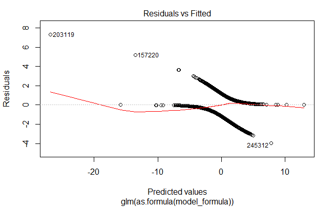

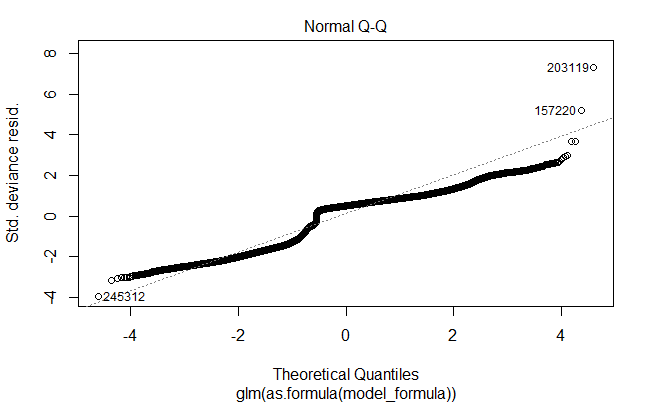

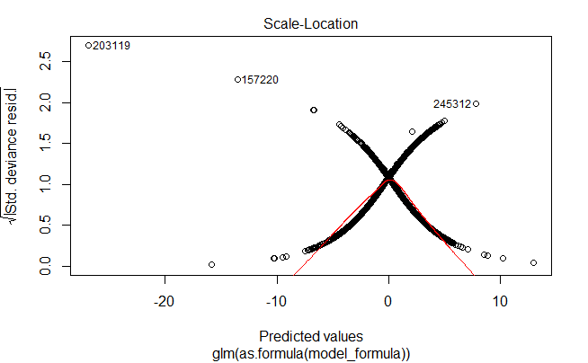

```
optimal cut threshold is
                 [,1]
sensitivity 0.7283715
specificity 0.6946105
cutoff      0.7174276
```

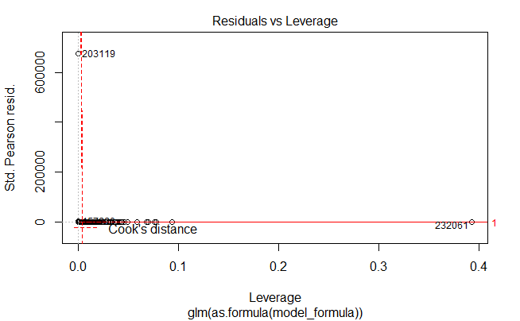

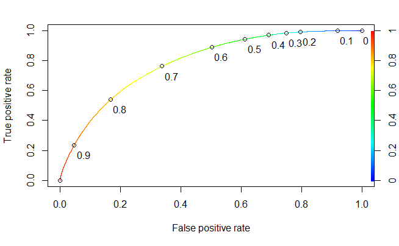

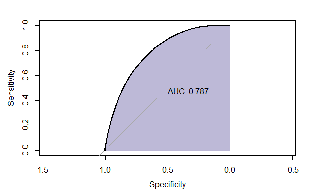

```r
model_2016_with_loan_to_value_ratio <-
build_glm_model("loan_granted~applicant_race_and_ethnicity+owner_occupancy+preapproval+log_loan_amount_000s+applicant_sex+county_code+tract_to_msamd_income+co_applicant_present+agency_code+minority_population+loan_to_income_ratio+loan_purpose+rate_spread+property_type+loan_to_value_ratio+respondent_id", new_train)

model_summary_and_plot(model_2016_with_loan_to_value_ratio, train = new_train)
```

```r
mcfadden_r_square(model_2016_with_loan_to_value_ratio, null_model)
```

```
Mcfadden Rsquare value
'log Lik.' 0.2083427 (df=106)
```

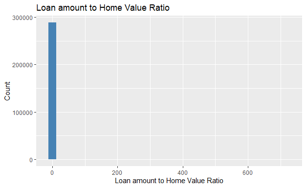

```r
ggplot(data = merged_hmda_with_loan_to_value_ratio, aes(x=loan_to_value_ratio)) +geom_histogram(fill = "steelblue") + labs(title = "Loan amount to Home Value Ratio" , x = "Loan amount to Home Value Ratio",y="Count")
```

```r
model6_fitted.probs <- predict(model_2016_with_loan_to_value_ratio, new_test, type = "response")

writeLines("")
```

```r
writeLines("Model with estimated loan to value ratio performance")
```

```
Model with estimated loan to value ratio performance
```

```
[1] "no"  "yes"
[1] "Accuracy 0.774871644164779"
Confusion Matrix and Statistics

          Reference
Prediction    no   yes
       no   8488  4576
       yes  8447 36336

               Accuracy : 0.7749
                 95% CI : (0.7714, 0.7783)
    No Information Rate : 0.7072
    P-Value [Acc > NIR] : < 0.00000000000000022

                  Kappa : 0.4173

 Mcnemar's Test P-Value : < 0.00000000000000022

            Sensitivity : 0.8882
            Specificity : 0.5012
         Pos Pred Value : 0.8114
         Neg Pred Value : 0.6497
             Prevalence : 0.7072
         Detection Rate : 0.6281
   Detection Prevalence : 0.7742
      Balanced Accuracy : 0.6947

       'Positive' Class : yes

Confusion Matrix and Statistics

          Reference
Prediction    no   yes
       no   8488  4576
       yes  8447 36336

               Accuracy : 0.7749
                 95% CI : (0.7714, 0.7783)
    No Information Rate : 0.7072
    P-Value [Acc > NIR] : < 0.00000000000000022
```

[output cut: 11 more lines]

```
   Detection Prevalence : 0.7742
      Balanced Accuracy : 0.6947

       'Positive' Class : yes

[1] "Precision not found"
[1] "Prevalence"
[1] "Precision and Recall"
[1] 0.8113793
[1] 0.8881502
[[1]]
[1] 0.8113793

[[2]]
[1] 0.8881502
```

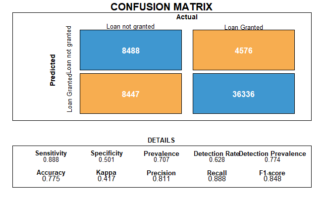

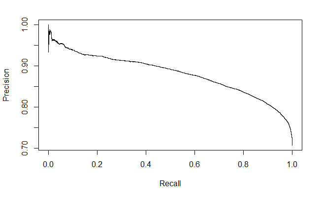

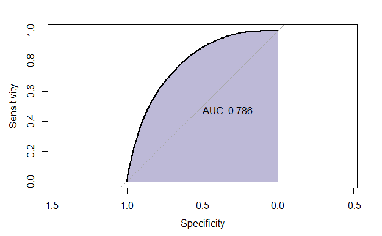

```r
print_model_performance(model6_fitted.probs, new_test, positive = "yes", negative = "no", threshold = 0.6)
```

# Save the models

```r
dir.create(model_path, showWarnings = FALSE)
save(model_2016_income_loan_amount, file = paste(model_path, "/model_income_loan_amount.rdata", sep=""))
save(model_2016_log_income_loan_amount, file = paste(model_path, "/model_log_income_loan_amount.rdata", sep=""))
save(model_2016_ratio_of_loan_to_income_with_log_of_income_and_amount, file = paste(model_path, "/model_loan_income_ratio_with_log_of_income_and_amount.rdata", sep=""))
save(model_2016_cross_val_loan_income_ratio, file = paste(model_path, "/cross_val_model.rdata", sep=""))
save(merged_2016_model, file = paste(model_path, "/merged_model.rdata", sep=""))

save(model_2016_with_loan_to_value_ratio, file = paste(model_path, "/merged_model_with_loan_to_value.rdata", sep=""))
```

# Save the train and test data for future reference.

```r
dir.create(model_data_path, showWarnings = FALSE)
save(train, file = paste(model_data_path, "/train.rdata", sep = ""))
save(test, file = paste(model_data_path, "/test.rdata", sep = ""))

dir.create(model_data_path, showWarnings = FALSE)
save(merged_train, file = paste(model_data_path, "/merged_train.rdata", sep = ""))
save(merged_test, file = paste(model_data_path, "/merged_test.rdata", sep = ""))

dir.create(model_data_path, showWarnings = FALSE)
save(new_train, file = paste(model_data_path, "/train_with_loan_to_value.rdata", sep = ""))
save(new_test, file = paste(model_data_path, "/test_with_loan_to_value.rdata", sep = ""))
```